# Computer Vision Project

Hello Enrique!

I’m happy to review your project today. I will mark your mistakes and give you some hints how it is possible to fix them. We are getting ready for real job, where your team leader/senior colleague will do exactly the same. Don't worry and study with pleasure!

Below you will find my comments - **please do not move, modify or delete them**.

You can find my comments in green, yellow or red boxes like this:

**Reviewer's comment**

Success. Everything is done succesfully.

**Reviewer's comment**

Remarks. Some recommendations.

**Reviewer's comment**

Needs fixing. The block requires some corrections. Work can't be accepted with the red comments.

You can answer me by using this:

**Student answer.**

Thank you so much for the feedback, I appreacaite it! I should have double checked before submitting. Thanks!

## Initialization

```python
import pandas as pd
import numpy as np
import matplotlib.pyplot as plt
```

## Load Data

The dataset is stored in the `/datasets/faces/` folder, there you can find

- The `final_files` folder with 7.6k photos
- The `labels.csv` file with labels, with two columns: `file_name` and `real_age`

Given the fact that the number of image files is rather high, it is advisable to avoid reading them all at once, which would greatly consume computational resources. We recommend you build a generator with the ImageDataGenerator generator. This method was explained in Chapter 3, Lesson 7 of this course.

The label file can be loaded as an usual CSV file.

```python
labels = pd.read_csv('/datasets/faces/labels.csv')
labels.head()
```

|  | file_name | real_age |
| --- | --- | --- |
| 0 | 000000.jpg | 4 |
| 1 | 000001.jpg | 18 |
| 2 | 000002.jpg | 80 |
| 3 | 000003.jpg | 50 |
| 4 | 000004.jpg | 17 |

```
Found 5694 validated image filenames.
```

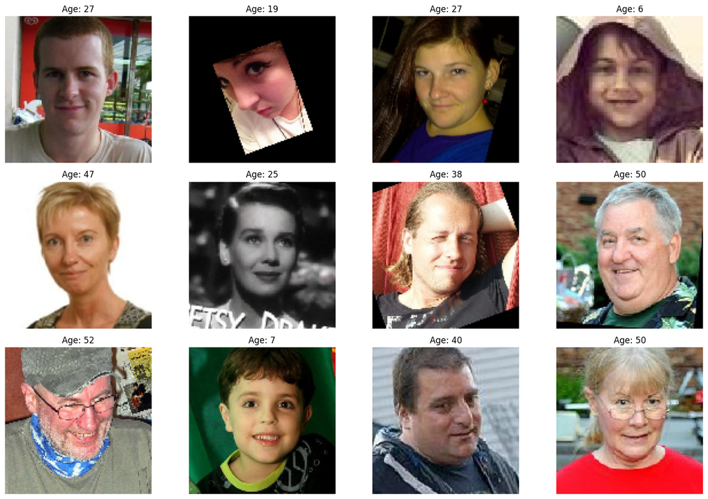

```python
from tensorflow.keras.preprocessing.image import ImageDataGenerator
datagen = ImageDataGenerator(rescale=1./255, validation_split=0.25)

generator = datagen.flow_from_dataframe(
    dataframe = labels,
    directory = '/datasets/faces/final_files/',
    x_col='file_name',
    y_col='real_age',
    target_size=(128, 128),
    batch_size=16,
    class_mode='raw',
    subset = 'training',
    seed = 12345)

images, ages = next(generator)

plt.figure(figsize=(15, 10))
for i in range(12):
    plt.subplot(3, 4, i+1)
    plt.imshow(images[i])
    plt.title(f'Age: {int(ages[i])}')
    plt.axis('off')
plt.tight_layout()
plt.show()
```

## EDA

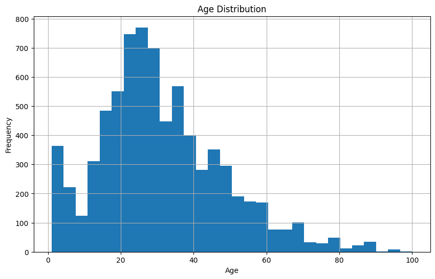

```
Dataset size: 7591 samples
```

```python
# Plot the age distribution
plt.figure(figsize=(10, 6))
labels['real_age'].hist(bins=30)
plt.title('Age Distribution')
plt.xlabel('Age')
plt.ylabel('Frequency')
plt.show()
print(f"Dataset size: {labels.shape[0]} samples")
```

### Findings

The model is fairly skewed to the right, this could potentially affect the model training as it could become bias towards ages under 40. We also notice that some of the images are augmented by being rotated and zoomed out. We cannot load every image at this moment, but augmentations likely are going to be a decent chunk of our data. This helps train the model since our objective (estimating age) is not changed by these augmentations.

**Reviewer's comment V1**

Good job! But what could you say about images? What about augmentations you see?

**Reviewer's comment V2**

Well done!

## Modelling

Define the necessary functions to train your model on the GPU platform and build a single script containing all of them along with the initialization section.

To make this task easier, you can define them in this notebook and run a ready code in the next section to automatically compose the script.

The definitions below will be checked by project reviewers as well, so that they can understand how you built the model.

```python
import pandas as pd

import tensorflow as tf

from tensorflow.keras.preprocessing.image import ImageDataGenerator
from tensorflow.keras.applications.resnet import ResNet50
from tensorflow.keras.models import Sequential
from tensorflow.keras.layers import GlobalAveragePooling2D, Dense, Dropout, Flatten
from tensorflow.keras.optimizers import Adam
```

```python
def load_train(path):

    """
    It loads the train part of dataset from path
    """
    labels = pd.read_csv(path + 'labels.csv')

    datagen = ImageDataGenerator(validation_split=0.25, rescale=1./255)

    train_gen_flow = datagen.flow_from_dataframe(
        dataframe=labels,
        directory=path + 'final_files/',
        x_col='file_name',
        y_col='real_age',
        target_size=(224, 224),
        batch_size=32,
        class_mode='raw',
        subset='training',
        seed=12345
    )

    return train_gen_flow
```

```python
def load_test(path):

    """
    It loads the validation/test part of dataset from path
    """
    labels = pd.read_csv(path + 'labels.csv')

    datagen = ImageDataGenerator(validation_split=0.25, rescale=1./255)

    test_gen_flow = datagen.flow_from_dataframe(
        dataframe=labels,
        directory=path + 'final_files/',
        x_col='file_name',
        y_col='real_age',
        target_size=(224, 224),
        batch_size=32,
        class_mode='raw',
        subset='validation',
        seed=12345
    )

    return test_gen_flow
```

**Reviewer's comment V1**

1. The correct path to the directory is: directory=path + 'final_files/'
2. To load labels you should use next path: path + 'labels.csv'

**Reviewer's comment V2**

Correct

```python
def create_model(input_shape):

    """
    It defines the model
    """
    backbone = ResNet50(weights='imagenet',
                        input_shape=input_shape,
                        include_top=False)

    model = Sequential()
    model.add(backbone)
    model.add(GlobalAveragePooling2D())
    model.add(Dense(1, activation='relu'))

    optimizer = Adam(learning_rate=0.0005)
    model.compile(optimizer=optimizer, loss='mse', metrics=['mae'])

    return model
```

```python
def train_model(model, train_data, test_data, batch_size=None, epochs=20,
                steps_per_epoch=None, validation_steps=None):

    """
    Trains the model given the parameters
    """
    if steps_per_epoch is None:
        steps_per_epoch = len(train_data)

    if validation_steps is None:
        validation_steps = len(test_data)

    model.fit(train_data,
              validation_data=test_data,
              batch_size=batch_size, epochs=epochs,
              steps_per_epoch=steps_per_epoch,
              validation_steps=validation_steps,
              verbose=2)

    return model
```

## Prepare the Script to Run on the GPU Platform

Given you've defined the necessary functions you can compose a script for the GPU platform, download it via the "File|Open..." menu, and to upload it later for running on the GPU platform.

N.B.: The script should include the initialization section as well. An example of this is shown below.

```python
# prepare a script to run on the GPU platform

init_str = """
import pandas as pd

import tensorflow as tf

from tensorflow.keras.preprocessing.image import ImageDataGenerator
from tensorflow.keras.applications.resnet import ResNet50
from tensorflow.keras.models import Sequential
from tensorflow.keras.layers import GlobalAveragePooling2D, Dense, Dropout, Flatten
from tensorflow.keras.optimizers import Adam
"""

import inspect

with open('run_model_on_gpu.py', 'w') as f:

    f.write(init_str)
    f.write('\n\n')

    for fn_name in [load_train, load_test, create_model, train_model]:

        src = inspect.getsource(fn_name)
        f.write(src)
        f.write('\n\n')
```

### Output

Place the output from the GPU platform as an Markdown cell here.

Epoch 1/20 178/178 - 56s - 312ms/step - loss: 108.6174 - mae: 7.9157 - val_loss: 569.9561 - val_mae: 18.8463 Epoch 2/20 178/178 - 56s - 314ms/step - loss: 74.5035 - mae: 6.6224 - val_loss: 389.3296 - val_mae: 14.7289 Epoch 3/20 178/178 - 60s - 335ms/step - loss: 47.7687 - mae: 5.2675 - val_loss: 374.7274 - val_mae: 14.8569 Epoch 4/20 178/178 - 78s - 440ms/step - loss: 34.1194 - mae: 4.4665 - val_loss: 104.2570 - val_mae: 7.8419 Epoch 5/20 178/178 - 56s - 314ms/step - loss: 24.9051 - mae: 3.8364 - val_loss: 85.0974 - val_mae: 6.9401 Epoch 6/20 178/178 - 55s - 309ms/step - loss: 20.1785 - mae: 3.4456 - val_loss: 82.5735 - val_mae: 6.8528 Epoch 7/20 178/178 - 55s - 308ms/step - loss: 17.1619 - mae: 3.1784 - val_loss: 112.9131 - val_mae: 8.4925 Epoch 8/20 178/178 - 82s - 462ms/step - loss: 14.0617 - mae: 2.8918 - val_loss: 74.2834 - val_mae: 6.5512 Epoch 9/20 178/178 - 55s - 308ms/step - loss: 13.0879 - mae: 2.7960 - val_loss: 84.0612 - val_mae: 6.8442 Epoch 10/20 178/178 - 83s - 466ms/step - loss: 12.9959 - mae: 2.7730 - val_loss: 77.5443 - val_mae: 6.8308 Epoch 11/20 178/178 - 82s - 460ms/step - loss: 13.0969 - mae: 2.7757 - val_loss: 80.6662 - val_mae: 6.8947 Epoch 12/20 178/178 - 56s - 313ms/step - loss: 11.9446 - mae: 2.6684 - val_loss: 94.2543 - val_mae: 7.6456 Epoch 13/20 178/178 - 55s - 309ms/step - loss: 11.0984 - mae: 2.5503 - val_loss: 78.5783 - val_mae: 6.7739 Epoch 14/20 178/178 - 55s - 307ms/step - loss: 12.0018 - mae: 2.6638 - val_loss: 81.5641 - val_mae: 6.7275 Epoch 15/20 178/178 - 56s - 313ms/step - loss: 10.7988 - mae: 2.5135 - val_loss: 79.8734 - val_mae: 6.8224 Epoch 16/20 178/178 - 86s - 485ms/step - loss: 11.7053 - mae: 2.6278 - val_loss: 116.2847 - val_mae: 8.0545 Epoch 17/20 178/178 - 56s - 315ms/step - loss: 14.6143 - mae: 2.9036 - val_loss: 109.5495 - val_mae: 8.1356 Epoch 18/20 178/178 - 55s - 309ms/step - loss: 17.1732 - mae: 3.1823 - val_loss: 95.6940 - val_mae: 7.1404 Epoch 19/20 178/178 - 55s - 309ms/step - loss: 16.5542 - mae: 3.1089 - val_loss: 106.0120 - val_mae: 7.9287 Epoch 20/20 178/178 - 55s - 307ms/step - loss: 11.5525 - mae: 2.5930 - val_loss: 86.2444 - val_mae: 6.9905 <Sequential name=sequential, built=True>

**Reviewer's comment V1**

It's better to change cell type from Markdown to Raw NBConvert to print the output in a good format

**Student answer.**

**Thanks I didn't know this!**

**Reviewer's comment V2**

You're welcome:)

## Conclusions

**Reviewer's comment V1**

You forgot to write a conclusion

**Reviewer's comment V2**

Thank you!

We have created the model for identifying age from faces. There was a point of diminishing returns where the model had trained sufficiently and additional epochs were not bringing much improvement and instead starting to dance around its best values. The MAE stabilized around 7, which was our baseline for success.

# Checklist

- Notebook was opened
- The code is error free
- The cells with code have been arranged by order of execution
- The exploratory data analysis has been performed
- The results of the exploratory data analysis are presented in the final notebook
- The model's MAE score is not higher than 8
- The model training code has been copied to the final notebook
- The model training output has been copied to the final notebook
- The findings have been provided based on the results of the model training